# Практическая работа №2

## Тема работы: "Графики"

##### Цель работы: составить графики и проанализировать их.

##### Ход работы:

```python
import pandas as pd # для работы с табличными данными и анализа временных рядов
import numpy as np # для эффективных математических операций с многомерными массивами
import matplotlib.pyplot as plt # для построения статических, анимированных и интерактивных визуализаций
import seaborn as sns # для создания статистических графиков на основе matplotlib с улучшенной эстетикой
```

```python
sns.set_palette("colorblind") # устанавливает цветовую палитру seaborn в режим "colorblind"
```

```python
path = r"C:\\Users\\Zumazoy\\Datasets\\youtube-top-100-songs-2025.csv"
df = pd.read_csv(path) # загружает данные из CSV-файла в DataFrame pandas
df.info() # выводит сводную информацию о DataFrame: структуру, типы данных и количество ненулевых значений
```

```
<class 'pandas.core.frame.DataFrame'>
RangeIndex: 100 entries, 0 to 99
Data columns (total 13 columns):
 #   Column                  Non-Null Count  Dtype
---  ------                  --------------  -----
 0   title                   100 non-null    object
 1   fulltitle               100 non-null    object
 2   description             100 non-null    object
 3   view_count              100 non-null    int64
 4   categories              100 non-null    object
 5   tags                    85 non-null     object
 6   duration                100 non-null    int64
 7   duration_string         100 non-null    object
 8   live_status             100 non-null    bool
 9   thumbnail               100 non-null    object
 10  channel                 100 non-null    object
 11  channel_url             100 non-null    object
 12  channel_follower_count  100 non-null    int64
dtypes: bool(1), int64(3), object(9)
memory usage: 9.6+ KB
```

#### 1. Countplot - это столбчатая диаграмма для визуализации количества наблюдений в каждой категории.

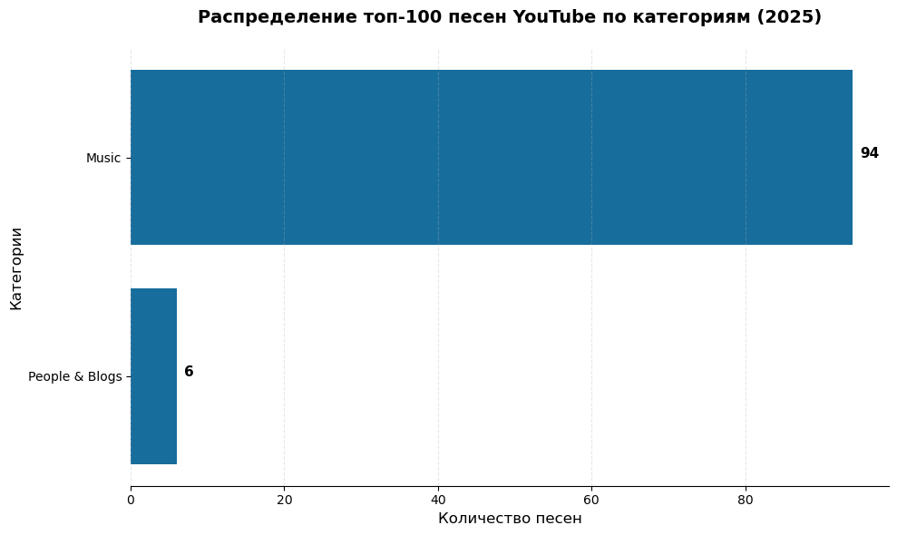

```python
plt.figure(figsize=(10, 6)) # создание графика размером 10×6 дюймов

# Построение горизонтального countplot
ax = sns.countplot(data=df, # countplot строит столбчатую диаграмму количества наблюдений
                   y='categories', # категории отображаются по вертикальной оси (горизонтальные столбцы)
                   order=df['categories'].value_counts().index) # сортирует категории по убыванию количества песен

# Настройка заголовка и подписей осей
plt.title('Распределение топ-100 песен YouTube по категориям (2025)',
          fontsize=14, fontweight='bold', pad=20) # заголовок с настройками шрифта и отступа
plt.xlabel('Количество песен', fontsize=12) # подпись оси X (количество песен)
plt.ylabel('Категории', fontsize=12) # подпись оси Y (категории)

# Добавление значений на столбцы
for p in ax.patches: # перебирает все столбцы графика
    width = p.get_width()  # получаем ширину столбца (количество)
    height = p.get_height()  # получаем высоту столбца
    y = p.get_y() + height / 2  # центр столбца по вертикали

    # Добавляем текст с количеством
    plt.text(width + 1, y, # смещает текст немного правее столбца
             f'{int(width)}', # пишем количество записей по категории
             fontsize=11,
             fontweight='bold')

# Добавление сетки для лучшей читаемости
plt.grid(axis='x', alpha=0.3, linestyle='--') # вертикальная сетка

# Улучшаем внешний вид
sns.despine(left=True)  # убираем рамку вокруг графика
plt.tight_layout() # автоматически подгоняет отступы

plt.show() # отображает график
```

Данный график показывает распределение топ-100 песен YouTube по категориям за 2025 год. На диаграмме явно видно доминирование музыкальной категории, которая включает подавляющее большинство песен из чарта.

#### 2. Barplot - это столбчатая диаграмма, отображающая средние значения числовых данных по категориям.

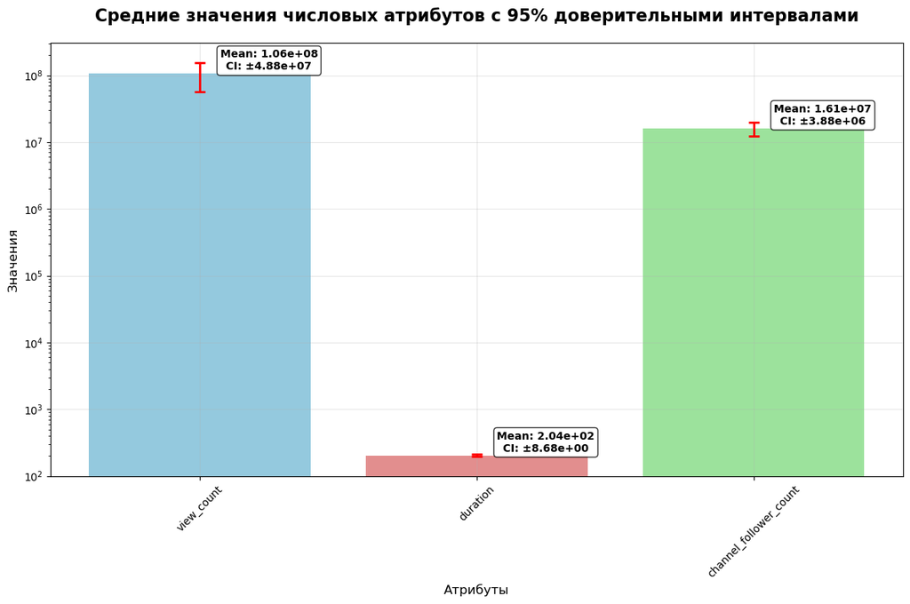

```python
numeric_columns = ['view_count', 'duration', 'channel_follower_count'] # три числовых атрибута для анализа

# Рассчитаем статистики заранее
stats_data = []
for col in numeric_columns:
    mean_val = df[col].mean() # среднее значение
    ci_val = 1.96 * df[col].std() / np.sqrt(len(df)) # 95% доверительный интервал по формуле: 1.96 × стандартное отклонение / √n
    stats_data.append({
        'attribute': col,
        'mean': mean_val,
        'ci': ci_val
    }) # cобираем результаты в структурированную таблицу

stats_df = pd.DataFrame(stats_data)

# Создаем barplot
plt.figure(figsize=(12, 8)) # создание столбчатой диаграммы размером 12×8 дюймов
ax = sns.barplot(data=stats_df, # barplot отображает средние значения для каждого атрибута
                 x='attribute', # определяет данные для оси X (в качестве меток используются названия атрибутов из колонки 'attribute')
                 y='mean', # определяет данные для оси Y (высота каждого столбца определяется значениями из колонки 'mean')
                 hue='attribute', # группирующий параметр для цветового кодирования (каждому уникальному значению из 'attribute' назначает свой цвет из палитры)
                 palette=['skyblue', 'lightcoral', 'lightgreen'], # palette назначает разные цвета каждому столбцу
                 legend=False) # legend=False скрывает легенду, так как подписи и так есть на оси X

# Ручное добавление доверительных интервалов
for i, (_, row) in enumerate(stats_df.iterrows()): # перебирает каждую строку со статистиками
    x_pos = i
    y_val = row['mean']
    ci_val = row['ci']

    # Добавляем линию ошибок
    ax.errorbar(x=x_pos, y=y_val, yerr=ci_val, # errorbar() добавляет вертикальные линии погрешностей
                color='red', linewidth=2, capsize=5, capthick=2)

    # Добавляем аннотацию
    ax.text(x_pos + 0.25, y_val + y_val*0.05,
            f'Mean: {y_val:.2e}\nCI: ±{ci_val:.2e}',
            ha='center', va='bottom', fontsize=10, fontweight='bold',
            bbox=dict(boxstyle="round,pad=0.3", facecolor="white", alpha=0.8)) # показывают точные значения среднего и доверительного интервала

plt.title('Средние значения числовых атрибутов с 95% доверительными интервалами',
          fontsize=16, fontweight='bold', pad=20)
plt.xlabel('Атрибуты', fontsize=12)
plt.ylabel('Значения', fontsize=12)
plt.yscale('log') # логарифмическая шкала plt.yscale('log') используется из-за большого разброса значений
plt.grid(True, alpha=0.3)
plt.xticks(rotation=45)
plt.tight_layout()
plt.show()
```

Данный график показывает средние значения трех ключевых метрик YouTube-видео: количества просмотров, длительности и подписчиков канала, дополненные 95% доверительными интервалами. Логарифмическая шкала позволяет наглядно сравнить показатели с разными порядками величин, а доверительные интервалы демонстрируют статистическую надежность оценок. Визуализация выявляет значительное превосходство показателей просмотров над другими метриками при высокой вариативности этих данных.

```python
# Находим экстремальные значения
max_mean_row = stats_df.loc[stats_df['mean'].idxmax()]
min_mean_row = stats_df.loc[stats_df['mean'].idxmin()]
max_ci_row = stats_df.loc[stats_df['ci'].idxmax()]

print(f"НАИБОЛЬШЕЕ СРЕДНЕЕ ЗНАЧЕНИЕ: '{max_mean_row['attribute']}'")
print(f"    Среднее: {max_mean_row['mean']:.2e}")

print(f"\nНАИБОЛЬШИЙ ДОВЕРИТЕЛЬНЫЙ ИНТЕРВАЛ: '{max_ci_row['attribute']}'")
print(f"    ±{max_ci_row['ci']:.2e}")

print(f"\nНАИМЕНЬШЕЕ СРЕДНЕЕ ЗНАЧЕНИЕ: '{min_mean_row['attribute']}'")
print(f"    Среднее: {min_mean_row['mean']:.2e}")
```

```
НАИБОЛЬШЕЕ СРЕДНЕЕ ЗНАЧЕНИЕ: 'view_count'
    Среднее: 1.06e+08

НАИБОЛЬШИЙ ДОВЕРИТЕЛЬНЫЙ ИНТЕРВАЛ: 'view_count'
    ±4.88e+07

НАИМЕНЬШЕЕ СРЕДНЕЕ ЗНАЧЕНИЕ: 'duration'
    Среднее: 2.04e+02
```

#### 3. Boxplot (ящик с усами) - это статистическая диаграмма, которая показывает распределение числовых данных через квартили.

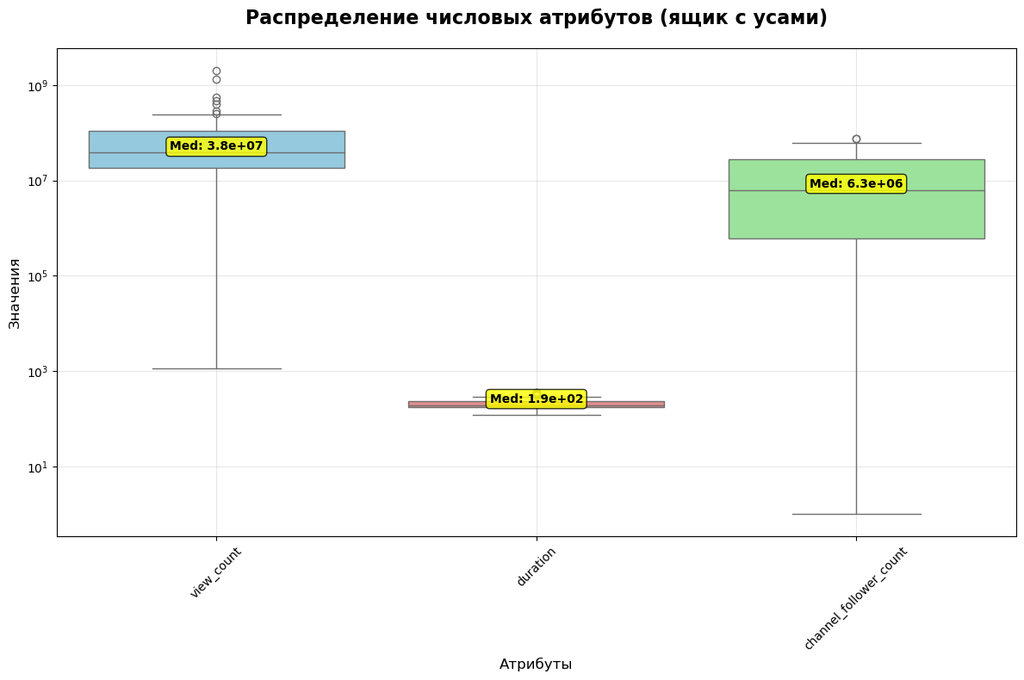

```python
# Создаем boxplot
plt.figure(figsize=(12, 8))
ax = sns.boxplot(data=df[numeric_columns], palette=['skyblue', 'lightcoral', 'lightgreen']) # boxplot() строит "ящики с усами" для трех числовых колонок

plt.title('Распределение числовых атрибутов (ящик с усами)',
          fontsize=16, fontweight='bold', pad=20)
plt.xlabel('Атрибуты', fontsize=12)
plt.ylabel('Значения', fontsize=12)
plt.yscale('log')
plt.grid(True, alpha=0.3)
plt.xticks(rotation=45) # поворачивает подписи по X на определенный угол

# Добавляем аннотации с медианами
medians = df[numeric_columns].median()
for i, median in enumerate(medians): # вычисляет медианы для каждого атрибута
    ax.text(i, median, f'Med: {median:.1e}', # i - позиция по оси X (0, 1, 2), median - значение медианы для позиции, f'Med: {median:.1e}' - форматирует число в научной нотации
            ha='center', va='bottom', fontsize=10, fontweight='bold',
            bbox=dict(boxstyle="round,pad=0.3", facecolor="yellow", alpha=0.8))

plt.tight_layout()
plt.show()
```

Данный график демонстрирует распределение трех ключевых метрик YouTube-видео, где каждый "ящик" представляет собой центральные 50% данных, а "усы" показывают диапазон типичных значений. Медианы, выделенные желтыми метками, видно что большинство видео имеют около 38 миллионов просмотров и 6 миллионов подписчиков, в то время как длительность контента сосредоточена вокруг 190 секунд. Визуализация также выявляет наличие выбросов - экстремально популярных видео, значительно превышающих средние показатели.

```python
boxplot_stats = {}

for col in numeric_columns:
    data = df[col].dropna()
    Q1 = data.quantile(0.25)
    Q3 = data.quantile(0.75)
    IQR = Q3 - Q1

    # Определяем выбросы
    lower_bound = Q1 - 1.5 * IQR
    upper_bound = Q3 + 1.5 * IQR
    outliers = data[(data < lower_bound) | (data > upper_bound)]

    boxplot_stats[col] = {
        'median': data.median(),
        'outliers_count': len(outliers)
    }

# Наибольшая медиана
max_median_attr = max(boxplot_stats.items(), key=lambda x: x[1]['median'])[0]
max_median_value = boxplot_stats[max_median_attr]['median']

# Наибольшее количество выбросов
max_outliers_attr = max(boxplot_stats.items(), key=lambda x: x[1]['outliers_count'])[0]
max_outliers_count = boxplot_stats[max_outliers_attr]['outliers_count']

# Наименьшее количество выбросов
min_outliers_attr = min(boxplot_stats.items(), key=lambda x: x[1]['outliers_count'])[0]
min_outliers_count = boxplot_stats[min_outliers_attr]['outliers_count']

print(f"НАИБОЛЬШАЯ МЕДИАНА: '{max_median_attr}'")
print(f"    Медиана: {max_median_value:.2e}")

print(f"\nНАИБОЛЬШЕЕ КОЛИЧЕСТВО ВЫБРОСОВ: '{max_outliers_attr}'")
print(f"    Выбросов: {max_outliers_count}")

print(f"\nНАИМЕНЬШЕЕ КОЛИЧЕСТВО ВЫБРОСОВ: '{min_outliers_attr}'")
print(f"    Выбросов: {min_outliers_count}")
```

```
НАИБОЛЬШАЯ МЕДИАНА: 'view_count'
    Медиана: 3.80e+07

НАИБОЛЬШЕЕ КОЛИЧЕСТВО ВЫБРОСОВ: 'view_count'
    Выбросов: 7

НАИМЕНЬШЕЕ КОЛИЧЕСТВО ВЫБРОСОВ: 'channel_follower_count'
    Выбросов: 2
```

#### 4. Heatmap (тепловая карта) - это график, который визуализирует матрицу числовых данных с помощью цветового кодирования, где интенсивность цвета соответствует величине значения.

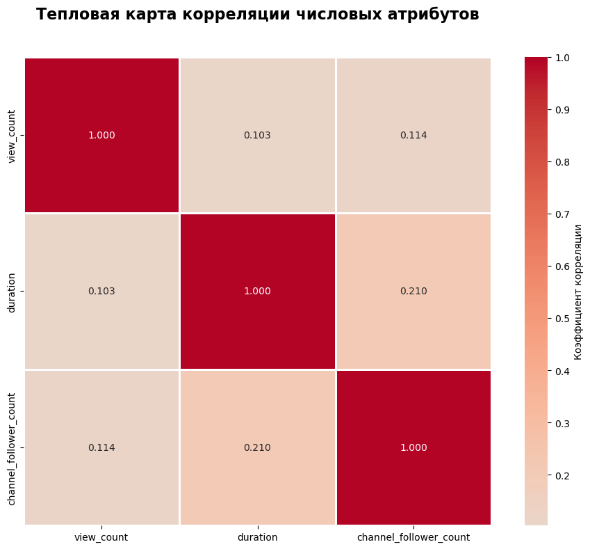

```python
correlation_data = df[numeric_columns]

# Рассчитываем матрицу корреляции
correlation_matrix = correlation_data.corr() # .corr() - вычисляет матрицу корреляции Пирсона между всеми парами переменных

# Создаем тепловую карту
plt.figure(figsize=(10, 8))

heatmap = sns.heatmap(correlation_matrix,
                      annot=True, # отображает числовые значения корреляции в каждой ячейке
                      cmap='coolwarm', # цветовая схема: синий для отрицательной, красный для положительной корреляции
                      center=0, # центрирует цветовую шкалу на нуле
                      square=True, # делает ячейки квадратными
                      fmt='.3f', # формат чисел: 3 знака после запятой
                      linewidths=1, # добавляет границы между ячейками
                      cbar_kws={'label': 'Коэффициент корреляции'}) # настраивает цветовую шкалу (colorbar)

plt.title('Тепловая карта корреляции числовых атрибутов\n',
          fontsize=16, fontweight='bold', pad=20)
plt.tight_layout()
plt.show()
```

Данная тепловая карта отображает корреляцию между тремя числовыми атрибутами YouTube-видео, используя цветовую шкалу от синего (отрицательная корреляция) через белый (нулевая) к красному (положительная). Значения коэффициентов корреляции, представленные в ячейках, показывают слабые положительные связи между всеми параметрами, наиболее заметную между длительностью и подписчиками (0.210). Визуализация позволяет быстро оценить отсутствие сильных линейных зависимостей между анализируемыми метриками.

```python
# Преобразуем матрицу в удобный формат для анализа
corr_pairs = []
for i in range(len(correlation_matrix.columns)):
    for j in range(i+1, len(correlation_matrix.columns)):
        attr1 = correlation_matrix.columns[i]
        attr2 = correlation_matrix.columns[j]
        corr_value = correlation_matrix.iloc[i, j]
        corr_pairs.append({
            'pair': f"{attr1} - {attr2}",
            'correlation': corr_value,
            'abs_correlation': abs(corr_value)
        })

corr_df = pd.DataFrame(corr_pairs)

# Находим экстремальные значения
max_corr_row = corr_df.loc[corr_df['abs_correlation'].idxmax()]
min_corr_row = corr_df.loc[corr_df['abs_correlation'].idxmin()]

negative_correlations = corr_df[corr_df['correlation'] < 0]
```

```python
print(f"НАИБОЛЬШАЯ КОРРЕЛЯЦИЯ:")
print(f"    {max_corr_row['pair']} = {max_corr_row['correlation']:.3f}")
print(f"    ПРАКТИЧЕСКАЯ ИНТЕРПРЕТАЦИЯ:")
if max_corr_row['correlation'] > 0:
    attr1, attr2 = max_corr_row['pair'].split(' - ')
    print(f"        Когда {attr1} увеличивается, {attr2} также имеет тенденцию к увеличению")
else:
    attr1, attr2 = max_corr_row['pair'].split(' - ')
    print(f"        Когда {attr1} увеличивается, {attr2} имеет тенденцию к уменьшению")

print(f"\nНАИМЕНЬШАЯ КОРРЕЛЯЦИЯ:")
print(f"    {min_corr_row['pair']} = {min_corr_row['correlation']:.3f}")
print(f"    ПРАКТИЧЕСКАЯ ИНТЕРПРЕТАЦИЯ:")
print(f"        Связь между этими признаками практически отсутствует")

print(f"\nХОЛОДНЫЕ ЦВЕТА (ОТРИЦАТЕЛЬНЫЕ КОРРЕЛЯЦИИ):")
if len(negative_correlations) > 0:
    for _, row in negative_correlations.iterrows():
        print(f"   • {row['pair']}: {row['correlation']:.3f}")
        attr1, attr2 = row['pair'].split(' - ')
        print(f"    Когда {attr1} ↑, то {attr2} ↓ (обратная зависимость)")
else:
    print(f"    Отрицательные корреляции не обнаружены")
```

```
НАИБОЛЬШАЯ КОРРЕЛЯЦИЯ:
    duration - channel_follower_count = 0.210
    ПРАКТИЧЕСКАЯ ИНТЕРПРЕТАЦИЯ:
        Когда duration увеличивается, channel_follower_count также имеет тенденцию к увеличению

НАИМЕНЬШАЯ КОРРЕЛЯЦИЯ:
    view_count - duration = 0.103
    ПРАКТИЧЕСКАЯ ИНТЕРПРЕТАЦИЯ:
        Связь между этими признаками практически отсутствует

ХОЛОДНЫЕ ЦВЕТА (ОТРИЦАТЕЛЬНЫЕ КОРРЕЛЯЦИИ):
    Отрицательные корреляции не обнаружены
```

#### 5. Pairplot (матрица диаграмм рассеяния) - это сетка графиков, которая показывает парные взаимосвязи между несколькими переменными в одном представлении.

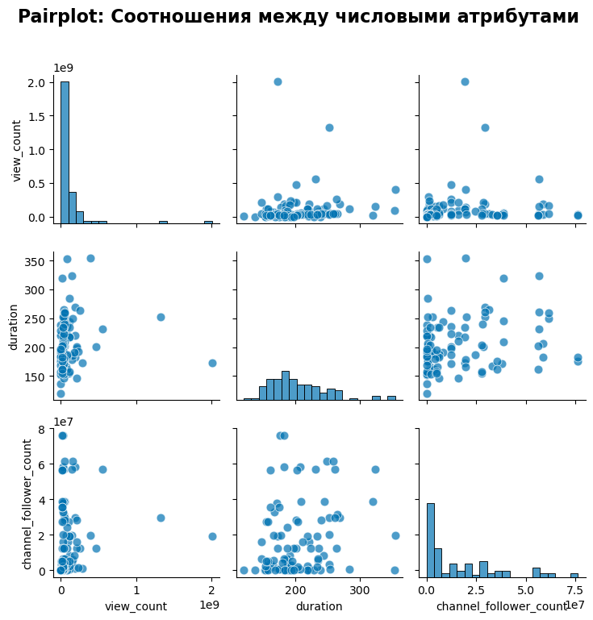

```python
pairplot_data = df[numeric_columns].dropna() # .dropna() удаляет строки с пропущенными значениями, чтобы избежать ошибок в построении графиков

plt.figure(figsize=(12, 10))
pairplot = sns.pairplot(pairplot_data,
                        diag_kind='hist',  # гистограммы на диагонали
                        plot_kws={'alpha': 0.7, 's': 60},  # настройки для точечных диаграмм рассеянияя: 'alpha' - прозрачность точек, 's' - размер точек (size)
                        diag_kws={'alpha': 0.7, 'bins': 20})  # настройки для гистограмм: 'bins' - количество интервалов группировки данных

pairplot.fig.suptitle('Pairplot: Соотношения между числовыми атрибутами', # fig.suptitle() добавляет общий заголовок ко всей матрице графиков
                      fontsize=16, fontweight='bold', y=1.02) # y регулирует вертикальное положение заголовка
plt.tight_layout()
plt.show()
```

Данный pairplot демонстрирует распределения и взаимосвязи между тремя числовыми атрибутами YouTube-видео. На диагонали расположены гистограммы, показывающие распределение каждого параметра, а вне диагонали - точечные диаграммы рассеяния, визуализирующие корреляции между парами переменных.

#### 6. Pie chart (круговая диаграмма) - это круговая визуализация, показывающая пропорциональное распределение данных по категориям, где каждый сегмент представляет долю от целого.

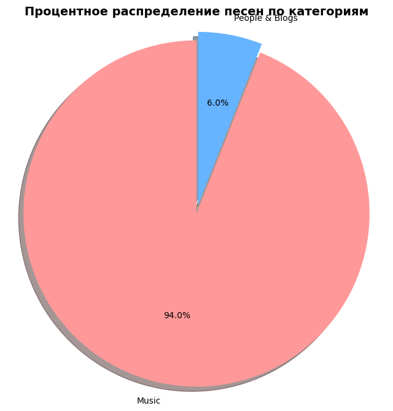

```python
category_counts = df['categories'].value_counts() # value_counts() подсчитывает количество записей в каждой категории

# Создание круговой диаграммы
plt.figure(figsize=(8, 8))

# Цвета для диаграммы
colors = ['#ff9999', '#66b3ff']
explode = (0.05, 0)  # выделяем первый сегмент

# Построение круговой диаграммы
plt.pie(category_counts.values, # числовые значения для каждого сегмента (количество песен)
        labels=category_counts.index, # подписи для сегментов (названия категорий)
        autopct='%1.1f%%', # автоматическое отображение процентов с одним знаком после запятой
        startangle=90, # начальный угол построения (90° = начало с верха)
        colors=colors, # задает цветовую схему: светло-красный и голубой
        explode=explode, # выдвигает первый сегмент на 5% для акцента
        shadow=True) # добавляет тень для объемного эффекта

plt.title('Процентное распределение песен по категориям', fontsize=14, fontweight='bold')
plt.axis('equal')  # обеспечиваем круглую форму диаграммы
plt.show()
```

Данная круговая диаграмма наглядно демонстрирует доминирование музыкальной категории в топ-100 YouTube, занимая 94% всего контента. Визуальное выделение большего сегмента подчеркивает абсолютное превосходство музыки над остальными категориями, в то время как небольшая доля "People & Blogs" (6%) показывает ограниченное присутствие немusicalного контента в чарте.

#### 7. PairGrid - это расширенная версия pairplot, предоставляющая полный контроль над типами графиков в разных секциях матрицы корреляций.

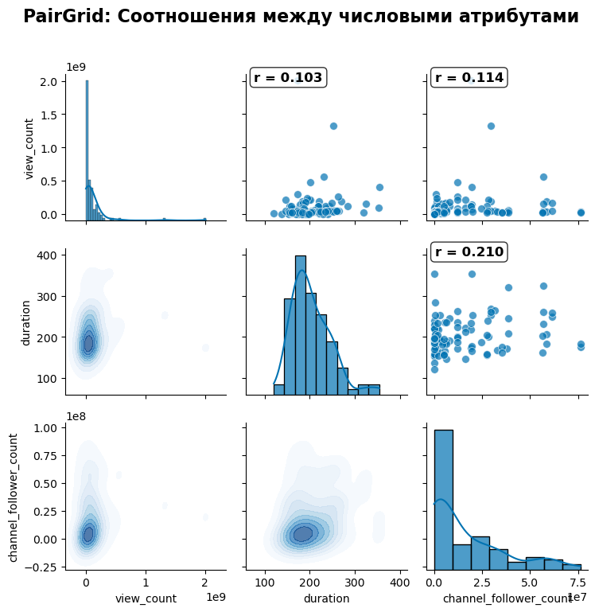

```python
g = sns.PairGrid(pairplot_data, diag_sharey=False) # PairGrid создает сетку для построения парных графиков с более гибким контролем, diag_sharey=False позволяет каждой диагональной гистограмме иметь свою шкалу Y
g.map_upper(sns.scatterplot, alpha=0.7, s=50)  # верхний треугольник - точечные диаграммы (scatter plots)
g.map_lower(sns.kdeplot, fill=True, cmap='Blues', alpha=0.7)  # Нижний треугольник - контурные диаграммы плотности (kdeplot)
g.map_diag(sns.histplot, kde=True, alpha=0.7)  # Диагональ - гистограммы с кривой плотности (KDE)

# Добавляем коэффициенты корреляции на верхние графики
for i, j in zip(*np.triu_indices_from(g.axes, 1)): # получает индексы верхнего треугольника (исключая диагональ)
    ax = g.axes[i, j]
    x_var = numeric_columns[j]
    y_var = numeric_columns[i]
    corr = pairplot_data[x_var].corr(pairplot_data[y_var])
    ax.text(0.05, 0.95, f'r = {corr:.3f}', transform=ax.transAxes,
            fontsize=12, fontweight='bold', bbox=dict(boxstyle="round,pad=0.3", facecolor="white", alpha=0.8))

plt.suptitle('PairGrid: Соотношения между числовыми атрибутами',
             fontsize=16, fontweight='bold', y=1.02)
plt.tight_layout()
plt.show()
```

Данный PairGrid комбинирует три типа визуализаций: точечные диаграммы в верхнем треугольнике показывают парные взаимосвязи, контурные карты плотности в нижнем треугольнике выявляют концентрации данных, а гистограммы на диагонали отображают распределения отдельных переменных. График дополнен коэффициентами корреляции, которые количественно подтверждают слабые положительные связи между всеми анализируемыми метриками, наиболее выраженную между длительностью и подписчиками (r=0.210).

##### Вывод: составлены графики количества значений категориального атрибута (countplot), среднего значения атрибутов (barplot), ящика с усами (boxplot), тепловой карты корреляции (heatmap) и были проанализированы.